# ARMA, ARIMA, and SARIMA Models

#### BPNZ - ARMA(1,1) Model

Next we’ll try an ARMA model for the sake of demo. (The requirement of stationarity is not actually met for this time series.)

```r
(arma11 <- arima(bpnz, order=c(1,0,1)))  # ARMA(1,1) model
```

```
##
## Call:
## arima(x = bpnz, order = c(1, 0, 1))
##
## Coefficients:
##         ar1    ma1  intercept
##       0.892  0.532      2.960
## s.e.  0.076  0.202      0.244
##
## sigma^2 estimated as 0.0151:  log likelihood = 25.14,  aic = -42.27
```

```r
AIC(arma11)
```

```
## [1] -42.27
```

```r
BIC(arma11)
```

```
## [1] -35.62
```

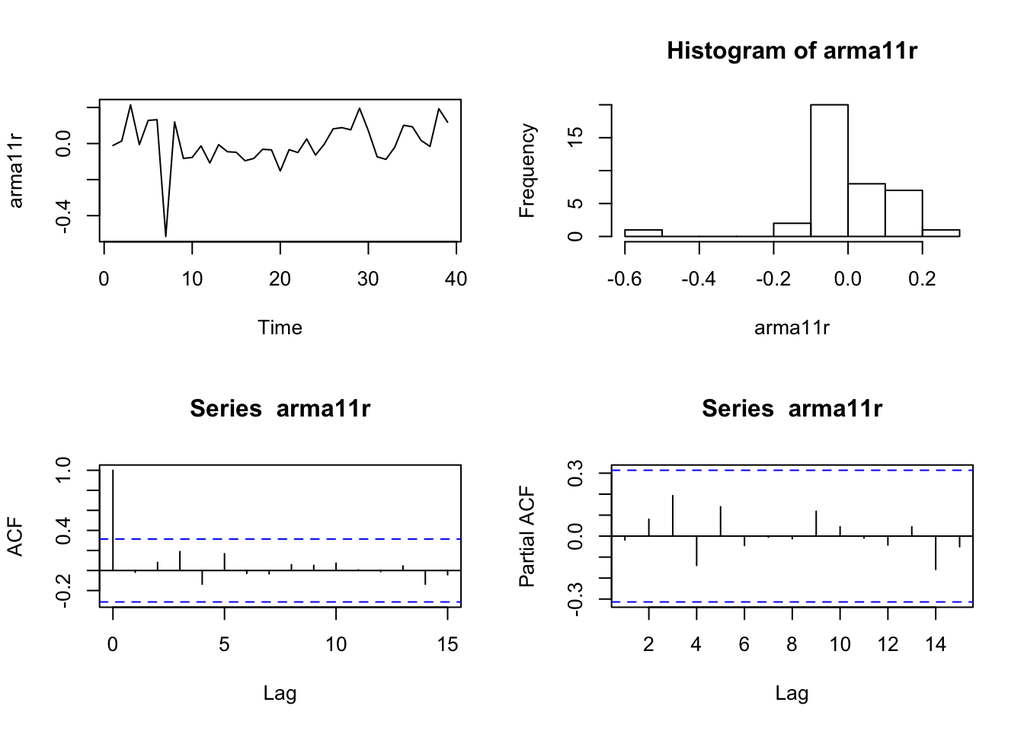

```r
arma11r <- resid(arma11)
par(mfrow=c(2,2))
plot(arma11r)
hist(arma11r)
acf(arma11r)
pacf(arma11r)
```

```r
Box.test(arma11r, type="Ljung-Box")  # using default of 1 lag
```

```
##
##  Box-Ljung test
##
## data:  arma11r
## X-squared = 0.014, df = 1, p-value = 0.9
```

Observations:

- AIC and BIC are both better than the MA(5) model
- residual TS plot looks more like white noise
- Ljung-Box test doesn’t reject H_0 of uncorrelated residual series
- ACF, PACF doesn’t show significant correlations

This looks like a better model for this data.

Now let’s look at in-sample fit and forecast.

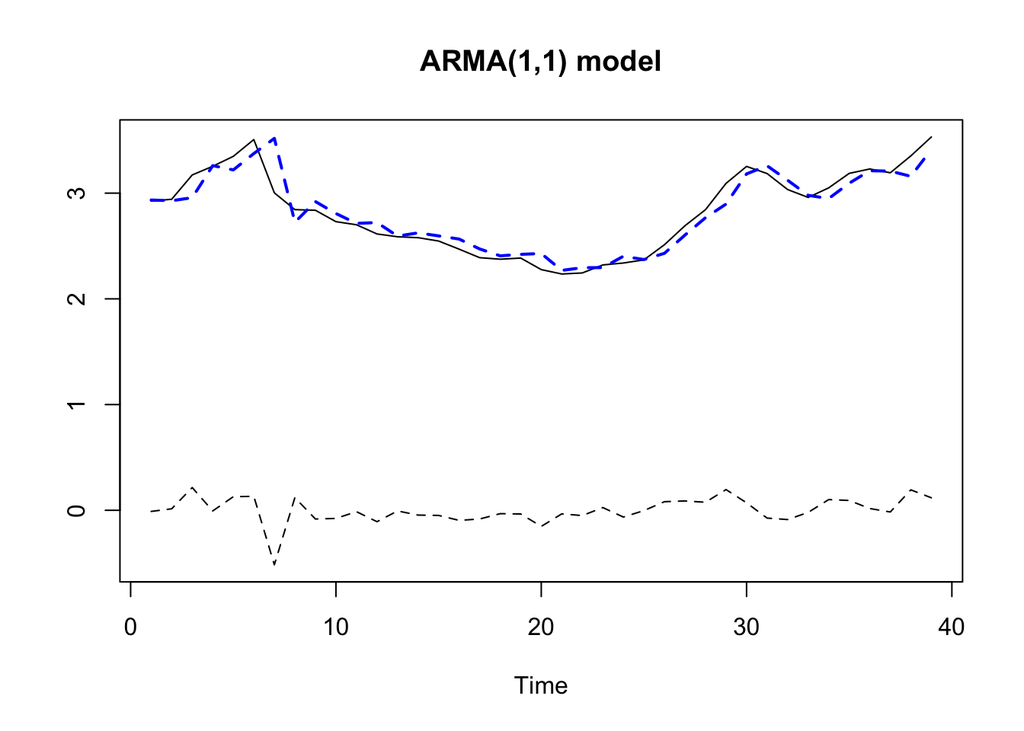

```r
par(mfrow=c(1,1))
ts.plot(bpnz, fitted(arma11), resid(arma11), lwd=c(1,2,1),
        lty=c('solid','dashed','dashed'), col=c('black','blue','black'),
        main='ARMA(1,1) model')
```

In-sample fit looks reasonable, although generally shifted slightly to the right of actual.

```r
(fcast <- forecast(arma11, h=6))
```

```
##    Point Forecast Lo 80 Hi 80 Lo 95 Hi 95
## 40          3.532 3.375 3.690 3.292 3.773
## 41          3.471 3.197 3.744 3.052 3.889
## 42          3.416 3.077 3.755 2.898 3.934
## 43          3.367 2.984 3.750 2.781 3.952
## 44          3.323 2.908 3.738 2.689 3.957
## 45          3.284 2.846 3.722 2.614 3.954
```

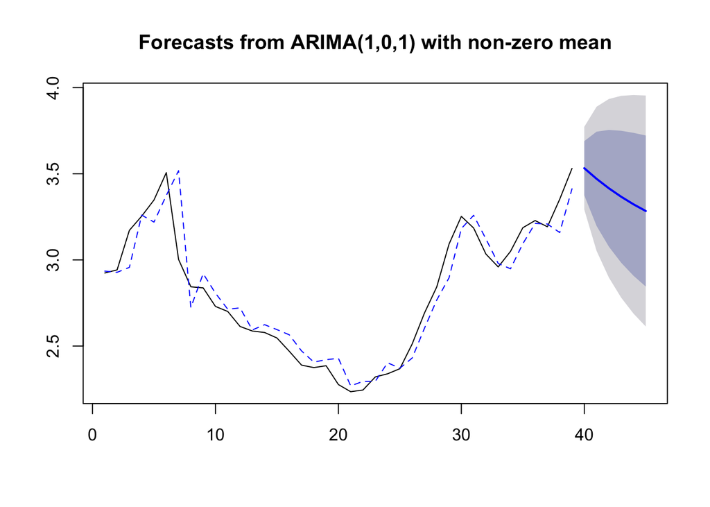

```r
plot(fcast)
lines(fitted(arma11), lty='dashed', col='blue')
```

Observations:

- forecast still trends downwards, but not as fast as the MA(5) model

Now, back-test, holding back 6 observations:

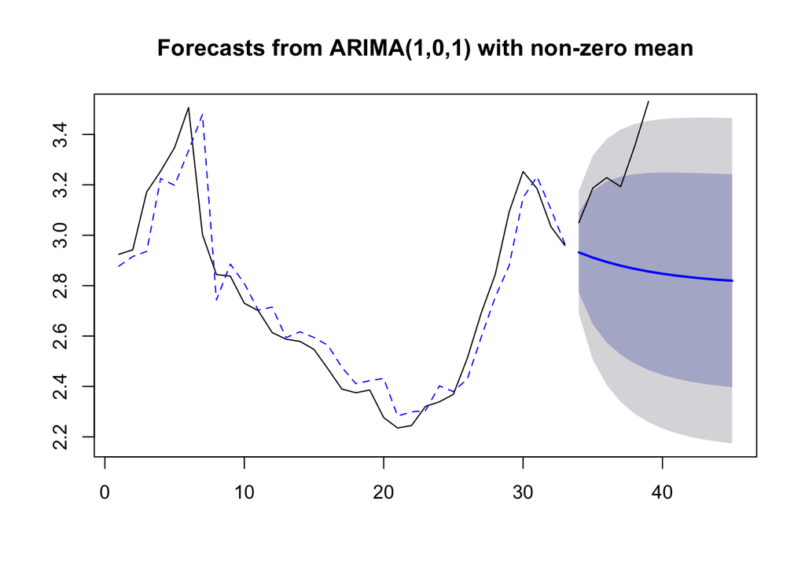

```r
arma11_bt <- arima(bpnz_bt, order=c(1,0,1))
fcast_bt <- forecast(arma11_bt, h=12)

par(mfrow=c(1,1))
plot(fcast_bt)
lines(window(bpnz, start=34), lty='solid', col='black')
lines(fitted(arma11_bt), lty='dashed', col='blue')
```

Observations:

- forecast still deviates from actual values
- the 95% confidence interval of the forecast includes most of the actuals

## ARIMA Models

ARIMA models are one way of dealing with *nonstationary* time series, which may have trends or seasonal effects. Simple “differencing” can off convert a *nonstationary* time series to a *stationary* one. Often a first-order differencing is sufficient (but generally we don’t want to go higher than 2nd order).

Note: not all nonstationary time series can be deal with by differencing. Notably, volatility clustering (conditional heteroskedasticity) that’s common in financial times series requires a different kind of model. Those are commonly model with Autoregressive Conditional Heteroskedastic (ARCH) models.

The term “integrated” arises from the fact that a differenced series needs to be aggregated in order to recover the original. The simplest $I(0)$ process is white noise; the simplest $I(1)$ process is the random walk (because after first differencing, we have a white noise model).

### First Differencing of a Random Walk

For example, a random walk has the following form:

$$x_t = x_{t-1} + w_t$$

Rearranged, we get a stationary white noise series $w_t \sim N(0,\sigma_w^2)$:

$$x_t - x_{t-1} \equiv \nabla x_t = w_t$$

Just a quick refresher as to random walk time series look like. Note that the drift term plays the same role as the slope in deterministic linear trend models.

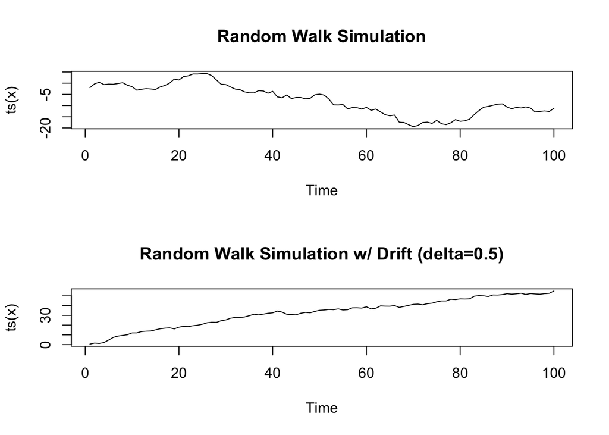

```r
par(mfrow=c(2,1))

# without drift
x <- w <- rnorm(100)
for (t in 2:length(x)) {
  x[t] <- x[t-1] + w[t]
}
plot(ts(x), main='Random Walk Simulation')

# with drift
x <- w <- rnorm(100)
del <- 0.5
for (t in 2:length(x)) {
  x[t] <- del + x[t-1] + w[t]
}
plot(ts(x), main='Random Walk Simulation w/ Drift (delta=0.5)')
```

As a reminder, the expectation value grows over time due to the drift:

$$E(x_t)=x_0 + t \delta$$

and the variance grows without bounds:

$$Var(x_t) = t \sigma^2$$

The autocovariance simplifies to:

$$\gamma_k = t \sigma^2$$

Because autocovariance is a function of time, this model is obviously *nonstationary*.

### First Differencing of a Linear Trend

First differencing can also remove deterministic trends. If we have linear trend of the following form, we can consider either first differencing (which results in an $MA(1)$ progress) or simply subtracting the trend (and analyzing residuals):

$$x_t = a + bt + w_t$$
$$\nabla x_t = x_t - x_{t-1} = (a - a) + (bt - b(t-1)) + (w_t - w_{t-1}) = b + w_t - w_{t-1}$$
Reducing and rewriting in terms of the lag operator, we have a stationary $MA(1)$ process:

$$\nabla x_t = b + \theta_q(B) w_t$$
Alternately, we could have subtracted the trend (instead of differencing) to achieve a white noise process:

$$x_t - (a + bt) = a + bt + w_t - (a + bt) = w_t$$
If our original time series showed increasing *variance* over time, we should try a log transformation (and then differencing, if there’s also a trend we want to try to remove).

### ARIMA Terminology

An $ARIMA(p,d,q)$ model is an $ARMA(p,q)$ model that’s applied after taking the $d^{th}$ difference of the original time series $x_t$. Using the lag operator, this can be expressed as:

$$\phi_p(B)(1-B)^d x_t = \theta_q(B) w_t$$

### Simulate an ARIMA time series and estimate it

Let’s simulate this model:

$$\nabla x_t (1 - 0.5B) = (1 + 0.3B)w_t$$
$$\nabla x_t = 0.5B \nabla x_t + (1+0.3B)w_t$$
$$\nabla x_t - 0.5 \nabla x_{t-1} = w_t + 0.3 w_{t-1}$$
We see that after applying the first differencing operator $\nabla$, the $ARIMA(1,1,1)$ model is transformed to an $ARMA(1,1)$ stationary model with an AR parameter $\phi_1 = 0.5$ and an MA parameter of $\theta_q=0.3$. (*Be careful of signs!*)

Let’s simulate this equation, and then compare plots between the original and the differenced equation:

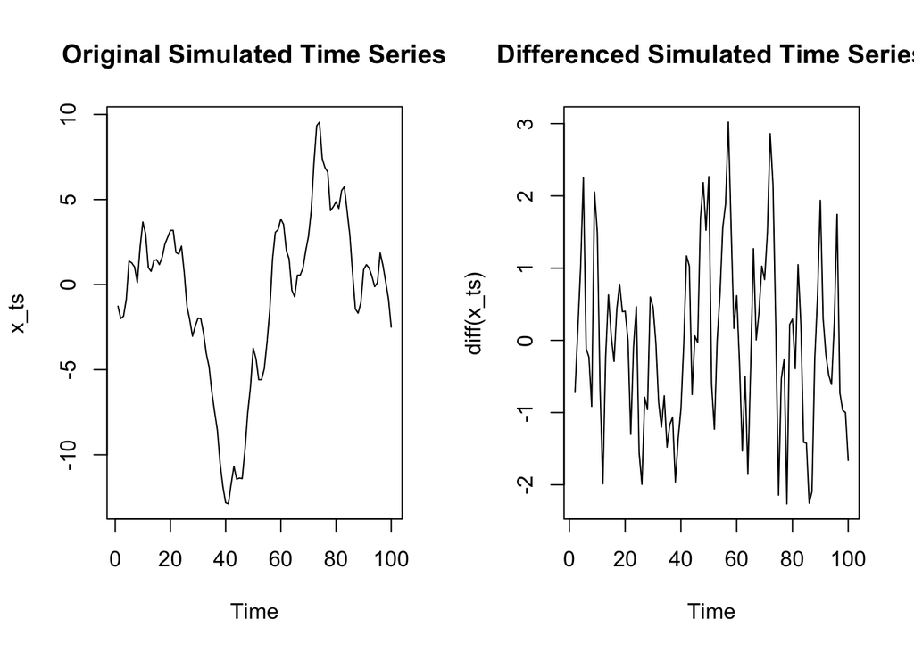

```r
x <- w <- rnorm(100)
for (t in 3:100) {
  x[t] = 0.5 * x[t-1] + x[t-1] - 0.5 * x[t-2] + w[t] + 0.3 * w[t-1]
}
x_ts <- ts(x)

# alternately, we could have asked arima.sim to run the simulation
# x_ts <- arima.sim(model=list(order=c(1,1,1), ar=0.5, ma=0.3), n=100)

par(mfrow=c(1,2))
plot(x_ts, main='Original Simulated Time Series')
plot(diff(x_ts), main='Differenced Simulated Time Series')
```

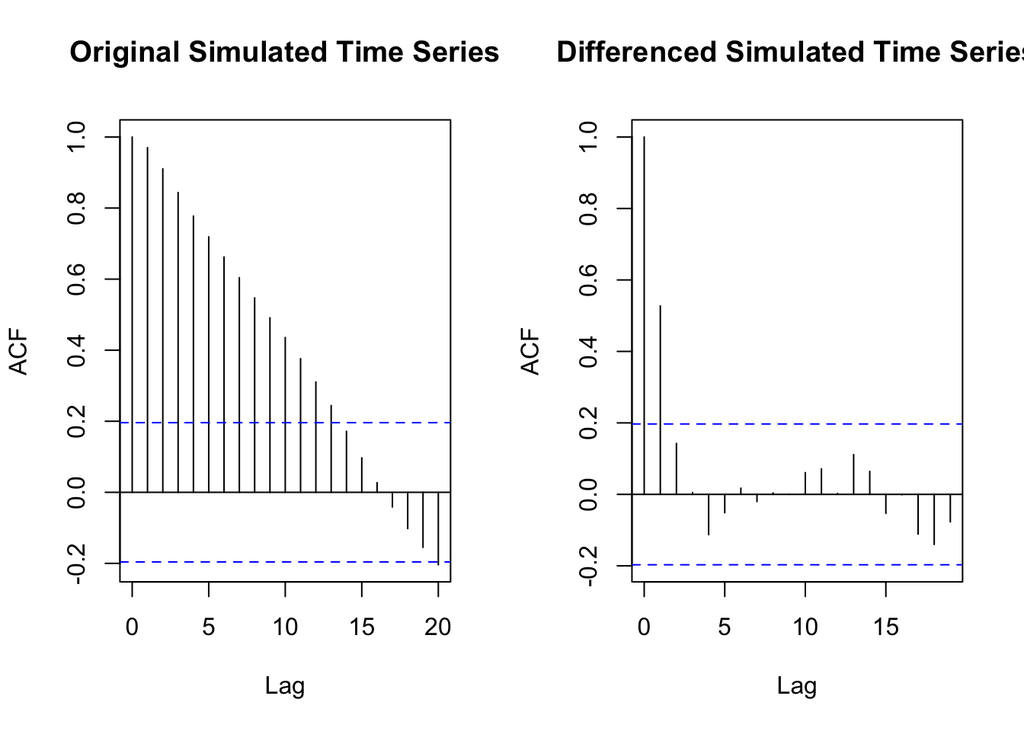

```r
acf(x_ts, main='Original Simulated Time Series')
acf(diff(x_ts), main='Differenced Simulated Time Series')
```

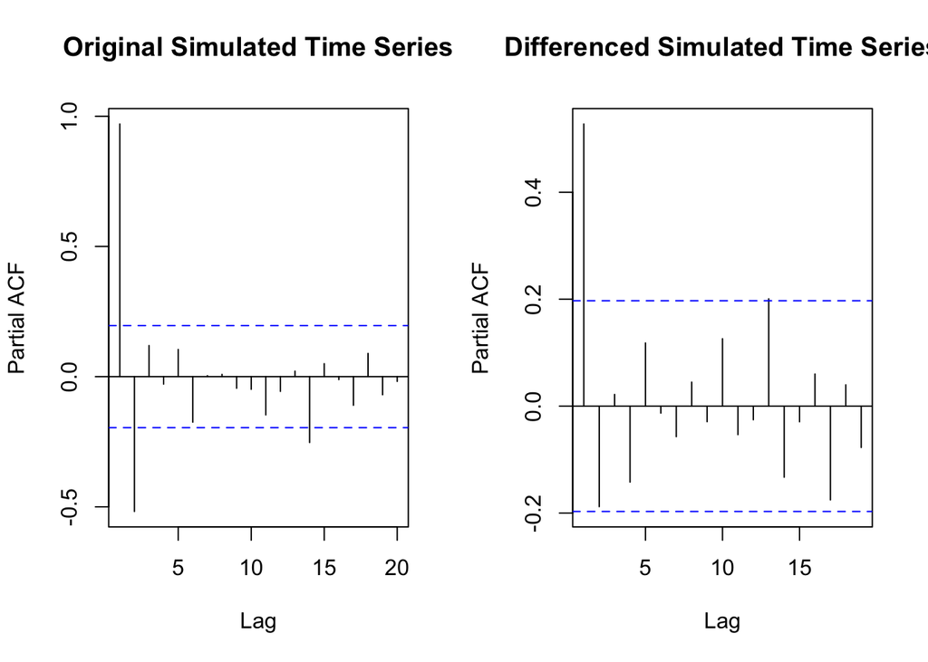

```r
pacf(x_ts, main='Original Simulated Time Series')
pacf(diff(x_ts), main='Differenced Simulated Time Series')
```

Now let’s estimate the model and plot the original and fitted time series.

```r
(arima111 <- arima(x_ts, order=c(1,1,1)))
```

```
##
## Call:
## arima(x = x_ts, order = c(1, 1, 1))
##
## Coefficients:
##         ar1    ma1
##       0.229  0.435
## s.e.  0.182  0.178
##
## sigma^2 estimated as 1.01:  log likelihood = -141,  aic = 288
```

```r
(arma11_diffed <- arima(diff(x_ts), order=c(1,0,1)))
```

```
##
## Call:
## arima(x = diff(x_ts), order = c(1, 0, 1))
##
## Coefficients:
##         ar1    ma1  intercept
##       0.229  0.435     -0.030
## s.e.  0.182  0.178      0.187
##
## sigma^2 estimated as 1.01:  log likelihood = -141,  aic = 290
```

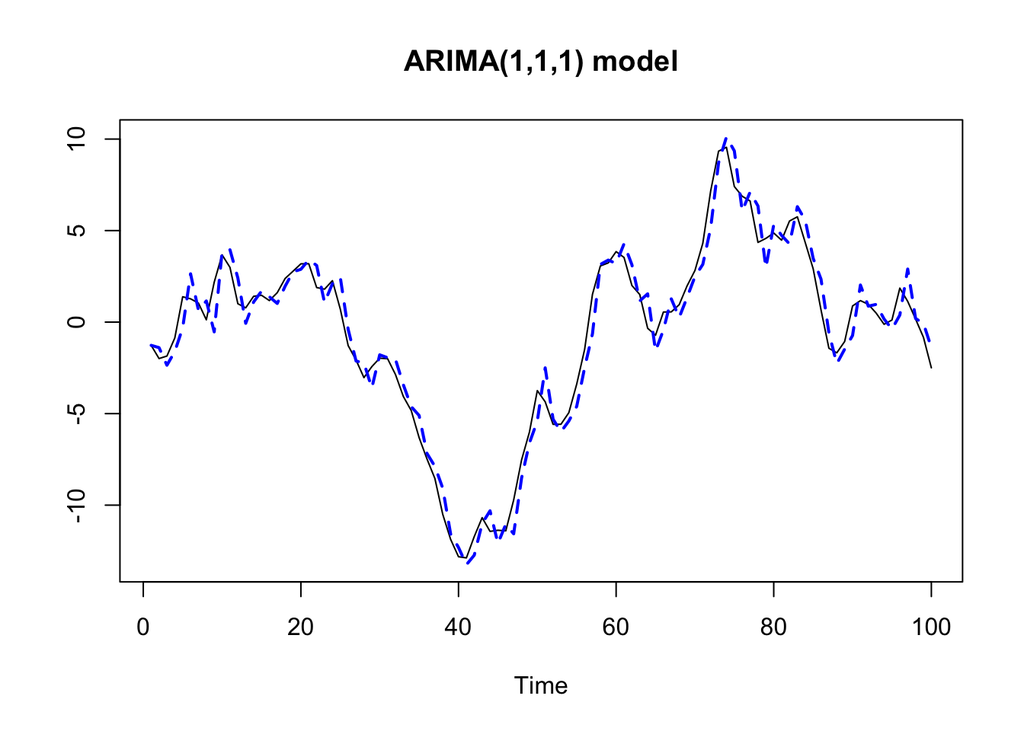

```r
par(mfrow=c(1,1))
ts.plot(x_ts, fitted(arima111), lwd=c(1,2),
        lty=c('solid','dashed'), col=c('black','blue'),
        main='ARIMA(1,1,1) model')
```

Now let’s do our standard diagnostics with the model’s residuals:

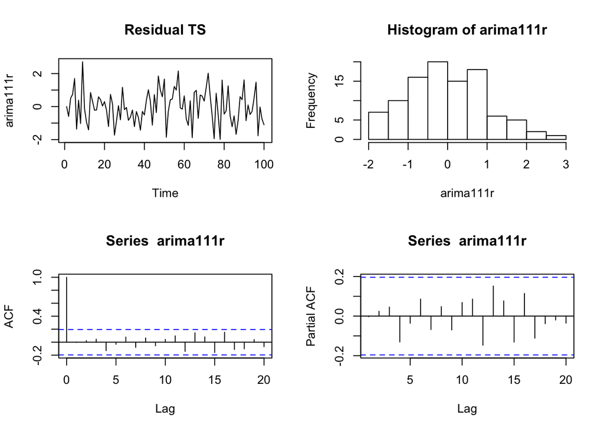

```r
arima111r <- resid(arima111)
par(mfrow=c(2,2))
plot(arima111r, main='Residual TS')
hist(arima111r)
acf(arima111r)
pacf(arima111r)
```

```r
Box.test(arima111r, type='Ljung-Box')
```

```
##
##  Box-Ljung test
##
## data:  arima111r
## X-squared = 0.00094, df = 1, p-value = 1
```

The plots and Ljung-Box test both fail to reject independence (ie. supporting the residual TS as a realization of a white noise process), indicating that we should be able to forecast with this model.

Let’s attempt forecasting:

```r
(fcast <- forecast(arima111, h=12))
```

```
##     Point Forecast   Lo 80   Hi 80   Lo 95  Hi 95
## 101         -3.357  -4.642 -2.0711  -5.323 -1.391
## 102         -3.554  -6.050 -1.0575  -7.371  0.264
## 103         -3.599  -7.017 -0.1805  -8.827  1.629
## 104         -3.609  -7.775  0.5562  -9.980  2.761
## 105         -3.612  -8.414  1.1910 -10.956  3.733
## 106         -3.612  -8.978  1.7536 -11.818  4.594
## 107         -3.612  -9.487  2.2630 -12.598  5.373
## 108         -3.612  -9.956  2.7318 -13.315  6.090
## 109         -3.612 -10.393  3.1683 -13.982  6.758
## 110         -3.612 -10.803  3.5784 -14.609  7.385
## 111         -3.612 -11.191  3.9663 -15.203  7.978
## 112         -3.612 -11.560  4.3353 -15.767  8.542
```

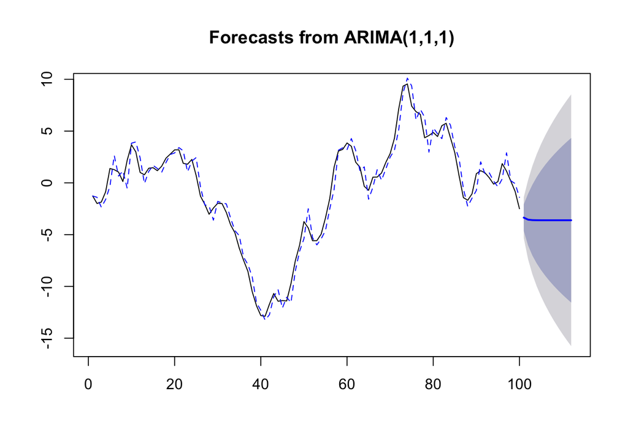

```r
par(mfrow=c(1,1))
plot(fcast)
lines(fitted(arima111), lty='dashed', col='blue')
```

We observe that while the model fit is good, the forecast is essentially a flat line. WHY???

## Review: General Steps in Time Series Analysis

1. Based on theory, subject matter knowledge, experience - choose a useful class of models
2. Cleanse the data
3. Conduct EDA: plot and examine main patterns, atypical observations:
   - Trend
   - Fluctuation around a trend (seasonal or cyclical/non-seasonal)
   - Sharp changes in behavior
   - Outliers
   - See if ACF, PACF plots suggest we should try $AR(p)$ or $MA(q)$ models
4. Examine and statistically test for stationarity
5. If not stationary (and model requires it), transform it:
   - Detrend
   - Remove seasonality
   - Log transformation (especially if variance increases with time)
   - Take 1-2 differences
6. Model TS with stationary or integrated TS model
7. Examine validity of model’s underlying assumptions:
   - Plot residual time series, histogram, ACF, and PACF (try to confirm resids look like white noise)
   - Ljung-Box test of the residual time series (failing to reject H_0 is good)
8. Among valid models, pick the one with best AIC, AICc, BIC, test set, etc… performance
9. Conduct inference and/or forecasting (only if model assumptions were validated!)